# XAI 3: Model-Agnostic methods

## EXERCISE:

Apply PDP to the regression example of predicting bike rentals. Fit a random forest approximation for the prediction of bike rentals (**cnt**). Use the partial dependence plot to visualize the relationships the model learned. Use the slides shown in class as model.

## QUESTION:

Analyse the influence of **days since 2011, temperature, humidity** and **wind speed** on the predicted bike counts.

````
```r

p1 <- ggplot(days_since,aes(x=days_since_2011,y=results$days_since_2011)) + geom_line() + geom_rug(aes(y=NULL)) + labs(x='Days since 2011',y='Prediction') + ylim(0,6050)

p2 <- ggplot(days_since,aes(x=temp,y=results$temp)) + geom_line() +
  geom_rug(aes(y=NULL)) + labs(x='Temperature',y='')+ ylim(0,6050)

p3 <- ggplot(days_since,aes(x=hum,y=results$hum)) + geom_line() +
  geom_rug(aes(y=NULL)) + labs(x='Humidity',y='')+ ylim(0,6050)

p4 <- ggplot(days_since,aes(x=windspeed,y=results$windspeed)) +
  geom_line() + geom_rug(aes(y=NULL)) + labs(x='Wind Speed',y='')+ ylim(0,6050)

# install.packages("patchwork", dependencies = TRUE)
library(patchwork)

p1 + p2 + p3 + p4 + plot_layout(ncol=4)
````

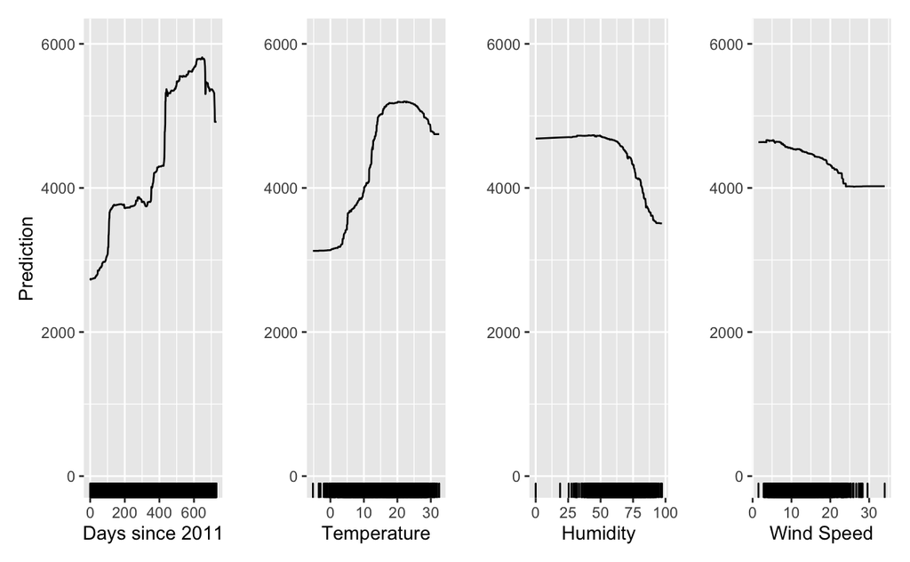

````r
```r

# sampled <- sample_n(......, 40)
````

La cantidad de bicis alquiladas se predice que ha ido generalmente en aumento desde 2011, pero, además, a mayor temperatura también más gente alquila la bici, encontrando un máximo alrededor de 20-25ºC, esta parece ser la temperatura óptima para salir a dar una vuelta, esta variable además actúa de forma inversa a la humedad, donde a mayor humedad menos interés hay en alquilar una bici (normalmente hay poca humedad en días de sol). Por último la velocidad del viento también tiene algo de influencia aunque menos que las demás, donde generalmente a mayor velocidad menos ganas hay de coger una bici, como cabría esperar.

## EXERCISE:

Generate a 2D Partial Dependency Plot with humidity and temperature to predict the number of bikes rented depending of those parameters.

BE CAREFUL: due to the size, extract a set of random samples from the BBDD before generating the the data for the Partial Dependency Plot.

Show the density distribution of both input features with the 2D plot as shown in the class slides.

TIP: Use geom_tile() to generate the 2D plot. Set width and height to avoid holes.

## QUESTION:

Interpret the results.

```r
sampled <- sample_n(days_since, 40)
temp <- sampled$temp
hum <- sampled$hum
th <- inner_join(data.frame(temp),data.frame(hum), by=character())
th$p <- 0

for(i in 1:nrow(th)){
  r <- days_since
  r[["temp"]] <- th[["temp"]][i]
  r[["hum"]] <- th[["hum"]][i]

  sal <- predict(rf, r)$predicted
  th[["p"]][i] <- sum(sal) / nr
}
```

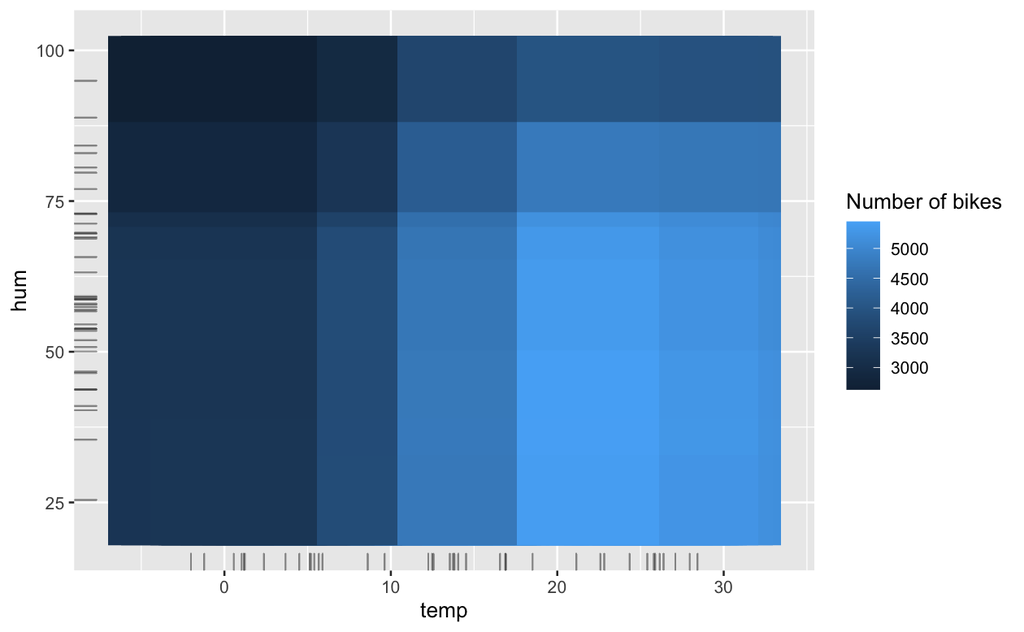

```r
p <- ggplot(th, aes(x = temp, y = hum, fill = p)) + geom_tile(width = 10, height = 15) + geom_rug(alpha = 0.01) +
  labs(fill = "Number of bikes")
p
```

El gráfico de este ejercicio es un mapa de color que nos indica la cantidad de bicis alquiladas dependiendo de la temperatura y la humedad. Podemos extraer conclusiones relativas a la hora de predecir la cantidad de alquileres:

- Si mantenemos la temperatura como constante, podemos observar que baja humedad no afectaría a la cantidad de bicis alquiladas, sin embargo, cuando esta humedad aumenta, sobrepasando 70%, vemos como se vería afectada negativamente la cantidad de bicis alquiladas, disminuyendo alrededor de 500 bicis.
- Por el contrario, si mantenemos constante la humedad, el incremento de temperatura afectaría positivamente al alquiler de bicis. Este comportamiento deja de ser así cuando se superan los 25º aprox. en el que el alquiler de bicis se ve reducido.
- Finalmente, si comprobamos las relaciones que hay entre ambos atributos, se puede afirmar que el momento en el que mayor alquiler de bicis hay es cuando la humedad es menor a 75% y la temperatura entre 18º y 25º, superando más de 5000 bicis alquiladas (Como hemos mencionado antes, la temperatura tiene un límite óptimo, a partir de ahí se empeoran los alquileres). También es conveniente indicar que cuando la humedad es muy alta >90% y la temperatura es muy baja <5º, la cantidad de bicis alquiladas en mínima, ni siquiera supera las 3000 bicis.

## EXERCISE:

Apply the previous concepts to predict the **price** of a house from the database **kc_house_data.csv**. In this case, use again a random forest approximation for the prediction based on the features **bedrooms**, **bathrooms**, **sqft_living**, **sqft_lot**, **floors** and **yr_built**. Use the partial dependence plot to visualize the relationships the model learned.

BE CAREFUL: due to the size, extract a set of random samples from the BBDD before generating the data for the Partial Dependency Plot.

## QUESTION:

Analyse the influence of **bedrooms, bathrooms, sqft_living** and **floors** on the predicted price.

```r
d <- read.csv("kc_house_data.csv")

sampled <- sample_n(d, 1000)

sampled <- select(sampled, bedrooms, bathrooms, sqft_living, sqft_lot, floors, yr_built, price)

rf <- rfsrc(price~., data=sampled)

results <- select(sampled, bedrooms, bathrooms, sqft_living, floors, price)
nr <- nrow(sampled)
for(c in names(results)[1:4])
{
  for(i in 1:nr){
    r <- sampled
    r[[c]] <- sampled[[c]][i]
    sal <- predict(rf, r)$predicted
    results[[c]][i] <- sum(sal) / nr
  }
}
```

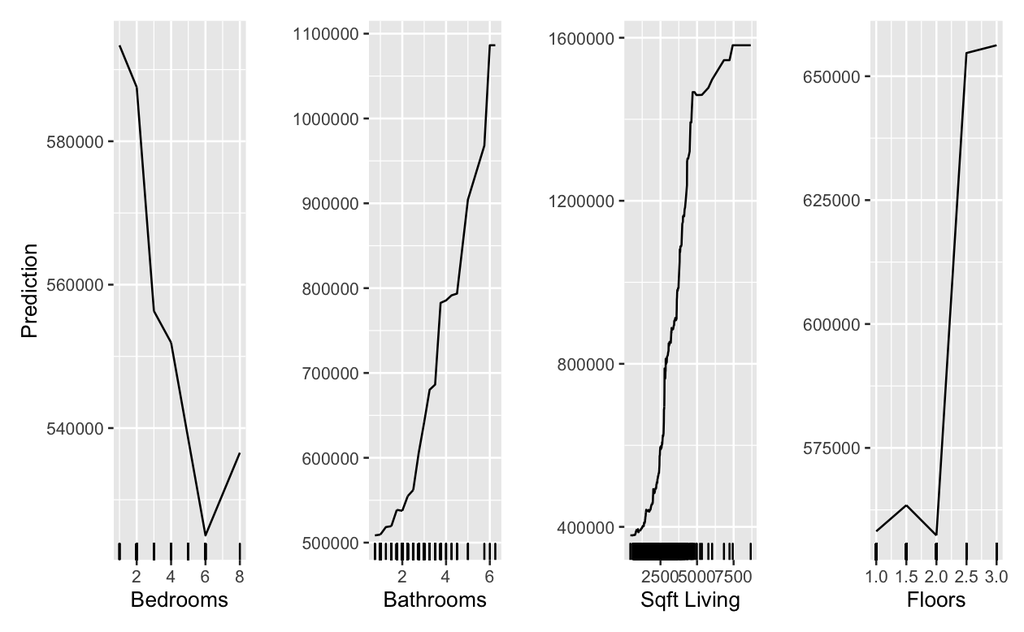

```r
p1 <- ggplot(sampled,aes(x=bedrooms,y=results$bedrooms)) + geom_line() + geom_rug(aes(y=NULL)) + labs(x='Bedrooms',y='Prediction')

p2 <- ggplot(sampled,aes(x=bathrooms,y=results$bathrooms)) + geom_line() +
  geom_rug(aes(y=NULL)) + labs(x='Bathrooms',y='')

p3 <- ggplot(sampled,aes(x=sqft_living,y=results$sqft_living)) + geom_line() +
  geom_rug(aes(y=NULL)) + labs(x='Sqft Living',y='')

p4 <- ggplot(sampled,aes(x=floors,y=results$floors)) +
  geom_line() + geom_rug(aes(y=NULL)) + labs(x='Floors',y='')

# install.packages("patchwork", dependencies = TRUE)
library(patchwork)

p1 + p2 + p3 + p4 + plot_layout(ncol=4)
```